# RadNet Exploratory Data Analysis with RStudio

Wendy Bisset

August 13, 2018

=============================================================

## Data Source and Background Information

The US Environmental Protection Agency maintains several public databases on environmental data.[^1] One such database, **RadNet**,[^2] is a system of geographically distributed stations which sample and test for a number of radiochemical analytes (e.g., gross beta (β), cesium-137, iodine-131) in the nation’s air, precipitation, and drinking water. RadNet provides historical data to estimate long-term trends in environmental radiation levels and as a means to estimate levels of radioactivity in the environment. The stations are located across the US as well as American Territories. The current RadNet database primarily consists of data collected since 1978 though some data dates back to 1973 from RadNet’s precursor, ERAMS (Environmental Radiation Ambient Monitoring System).

All data was downloaded in September 2017 as .csv files from the RadNet website. According to the EPA’s [Envirofacts Data Service API](https://www.epa.gov/enviro/web-services) data output is limited to 10000 rows of data at a time from a maximum of three tables. Consequently, the data for each media type was downloaded by decade (up-to 1989, 1990-1999, 2000-2009, 2010-2017) and the resulting .csv files were loaded into RStudio and then merged[^3] into a single R dataframe.

Variables include units of measure, e.g. size of sample (g, L) or time of decay (sec, min, hour, day, year). No filters or limitations were placed on location or types of radionuclides analysed. Other variables such as project numbers, surface water locations, sample collection start etc., exist in the RadNet database, but in effort to to control file size and project scope, these variables were not downloaded.

## Data Overview and Tidying -

The original raw consolidated dataframe has 19 variables and 504092 observations. One variable was added as a tracker in the merge operation to track the media dataframe from which the observation originated. From a cursory glance, variables of interest are monitoring station locations, sample types collected, and analytes. Dates and analysis amounts will be helpful in the investigation of these variables. Several variables are added during the course of the anaylsis to provide methods for displaying locations or for easy summarization of other variables and categories. These new variables will be introduced as they are generated.

Variable names were shortened and several variables were recast as factors with ordered levels where it made sense that an inmposed order may be useful, e.g., S(econd) < M(inute) < H(our) < D(ay) < Y(ear). In the event of possible date manipulations, the date field was changed to type DATE instead of CHR.[^4]

## Univariate Review

A simple analyses of each variable (count, table, summary, or distribution) greatly helped to understand a bit more about the data. The first variables of interest were those dealing with location; city and state information provides potention to visualizing data spatially.

### Variable Overivews

##### Location Numbers, Cities, and States

There are 324 unique sampling locations with a numerical LOC_NUM tied to one of 280 cities in the US, US territories, the Pananma Canal (PC) or Ottawa, Canada (ON). The entries are not evenly distributed amongst the monitoring sites. Additionally, several cities have multiple monitoring stations. Oakridge, Tennesse tops this list with 11 different monitoring location numbers.

| STATE_ABBR | CITY_NAME | n |
| --- | --- | --- |
| TN | OAK RIDGE | 11 |
| PA | PHILADELPHIA | 5 |
| AL | MONTGOMERY | 3 |
| MN | WELCH | 3 |
| NV | LAS VEGAS | 3 |
| AZ | PHOENIX | 2 |
| CA | SAN FRANCISCO | 2 |
| CO | DENVER | 2 |
| GA | ATLANTA | 2 |
| IL | CHICAGO | 2 |

Some sites have have $\geq$ 12,000 entries while others have only a single entry. Highly monitored states have $\geq$ 20,000 entries while some areas have < 500 entries. The top and bottom five locations, by either city or state, can be tabularized by number of observations for that location or area.

[output not shown]

[output cut: 282 more lines]

Simple research showed that the package `ggmap`[^5] could make it possible to represent location information geographically.[^6]<sup>,</sup>[^ggmap_vis2] Using the provided city and state information, the variables, latitude and longitude, were added for each location using the `geocode()` function.[^7]<sup>,</sup>[^8] The packages `choroplethr` and `choroplethrMaps` also allow for geographical representation of various values on a shaded and keyed `Choropleth Map`.[^9]<sup>,</sup>[^10]

##### Sample Types

Of the half million observations about one-half are air samples (air-filter + air-charcoal).

```
    AIR-CHARCOAL       AIR-FILTER   DRINKING WATER PASTEURIZED MILK
             830           249905            41065            84249
   PRECIPITATION    SURFACE WATER
          113825            14218
```

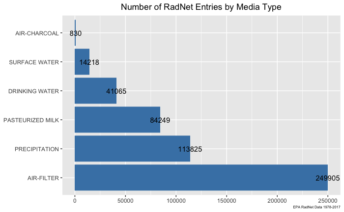

##### Sample IDs and Analytes

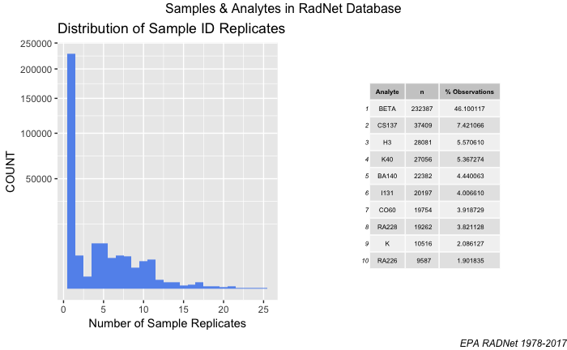

##### Sample Sizes and Units of Measure

The sample sizes for each observation are interestingly grouped about the values 1, 5 and 5,000. This is not actually a valid comparison of sizes as the *unit size* is needed to provide a true comparison. The units, while indicating relative size also indicate sample type: i.e., mL and L are for liquids; mg and g for solids and ($m^3$) is for gas samples. A small fraction of entries have no designated unit (NA), while about $\frac{1}{2}$ of the measured units are for gases ($m^3$).

Tying this to the earlier observations of the predominants sample type and analyte, it is likely that $\frac{1}{2}$ of the observations in this database are gross beta measurements in air samples ($m^3$). The next biggest group of units is the liter (L) which matches well with the remaining sample types being liquids: i.e, precipitation, milk, and water (drinking & surface)

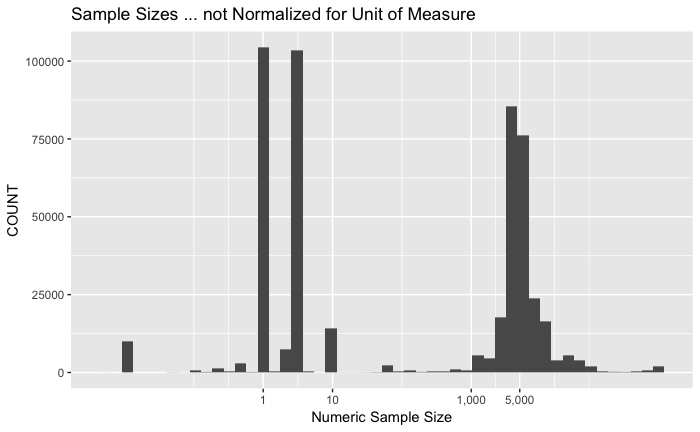

```
            G      L     M3     MG     ML
  3206     15 231564 250729    434  18144
```

##### Analytical Procedures and Duration

There are 35 analytical procedure numbers with **Procedure 1** returned as the mode of this variable (~42% of the entries). Procedures 1 and 9 account for 74% of the entries and a small high density grouping about 120 shows procedures 118 and 119 accounting for another 19 % of the entries. Thus, most (93%) of the entries are analyzed with one of four procedures. A duration variable indicates that while most tests take under 20 hours there are some tests/procedures which are over 80 hours.

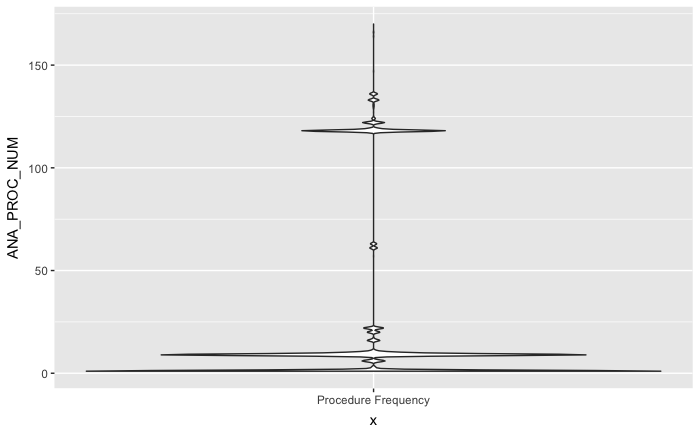

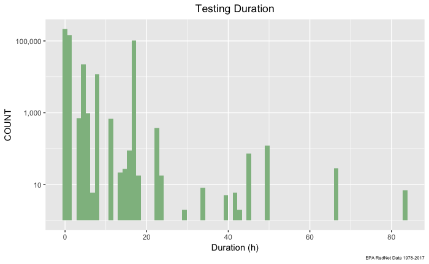

##### Result Amounts, MDC, CSU, and Units of Measure

Results amounts like sample sizes cannot be directly compared as this is more or less meaningless without a Result Unit.

One can plot the raw result values which show the greatest density around 0.01. The overlayed plots of the minimum detectable concentration (MDC) and combined standard uncertainty (CSU) shows that both MDC and CSU have their greatest density at <0.001, a factor of 10 lower than the results. This is reassuring as the uncertainties in the measurement should be much less than the actual measurment. Though this would need confirmation through examination of the unit of measurement.

Result units themselves are distributed very similar to the sample units with about $\frac{1}{2}$ of the measured units being for gases (pCi/m<sup>3</sup> and aCi/m<sup>3</sup>). Again this is in line with the observation that $\frac{1}{2}$ of the material IDs are for air samples.

An interesting observation is that 16% (81,921) observations have no result entry, result amount is NA. This seems odd as RadNet is designed specifically for the documentation of analtye concentrations, i.e., results.

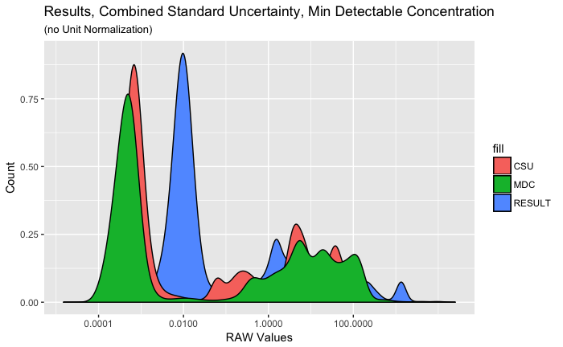

```
ACI/M3 DPM/GC    G/L  PCI/L PCI/M3
 22966     63  10585 242708 227770
```

| is.na(rad_data_raw$RESULT_AMOUNT) | n |
| --- | --- |
| FALSE | 422171 |
| TRUE | 81921 |

##### Result Dates

When examing result dates, one notices that the typical count ranges from about 125 to 250 entries, but there are regular spikes 50% to 100% above the baseline. These spikes occur on annual intervals; until 2010 the spikes are at mid-year (7/1) afterwhich they appear year-end (12/31).

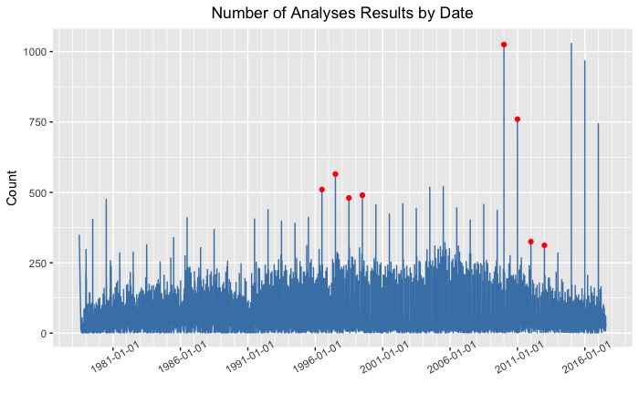

##### Analysis Types and Half-Lives

Not surprisingly RadNet, consists predominantly of radioactive (R) analyses (97.9 %) as opposed to elemental (E) analyses. While the majority of measurement is for radioactive component, only 50% of the entries include a radioactive half-life ($t_{1/2}$). This is is supported from the observation that gross beta accounts for 50% of the entries. A half-life is only defined for the single isotope of an particular element, gross beta is not isotope specific.

Half-life values by themselves are like sample size and result amount and cannot be compare directly. However these values can be converted to a single time unit *years* and then compared. This wonderfully captures the breadth of half-lives that is involved within this group of isotopes. The shortest-lived isotope, radon-219 has $t_{1/2}$ of 3.9 seconds compared to the longest-lived isotope, lanthanum-138 with $t_{1/2}$ = 1.05x10<sup>11</sup>, 105 billion years.

```
     E      R
 10585 493507
```

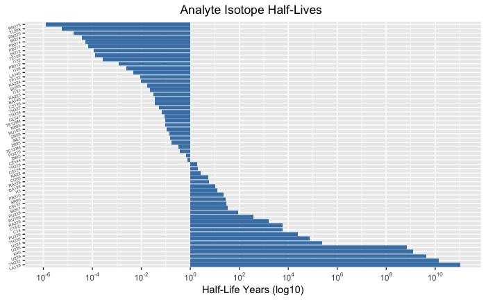

### Univariate Analysis Critique

#### Dataset structure:

In review, the original dataframe had 504,092 entries with 19 variables. The variables represent different factors (some levelled), numerical values, characters and dates. Some of the variables were recast for uniformity and to help data manipulation and representation. Most notably the dates were converted to date characters in ISO 8601 format.

#### Main features of interest:

- prime analysis types
  - materials sampled (milk, air, water: surface and precipitation)
  - analytes reviewed and potential results
- geographic information and distribution
- empty result entries (NANs)

#### Support features in the dataset:

Many of the variables have proved to be useful in the examination of the features of interest. For example, sample IDs helped search for duplicate entries, while procedure numbers and duration can help elucidate the effort and time involved for analysis of a single sample. Dates in combination with Location IDs can help isolate groups of data and help pinpoint any Radioactive release events or concerns.

#### New variables created from existing variables:

Several new variables were created, especially for the handling of the geographical information, e.g., latitude and longitude. The R packages `ggmap` and `choroplethr` and the API with `geocode` all require specific formatting of input data which in turn required reformatting of variables, e.g., NM to new mexico. Additionally, better handling and representation of NA values led to the creation of a couple of variables specifically to identify “complete” entries. Additionally, a date range variable was introduced to help filter data by ranges.

#### Data Cleansing/Unusual Distributions:

Besides the missing result data, there is any interesting long tailed positive skew for the distribution of sample replicates.

Column names were tidied and shortened. Most cleaning and date munging involved verifying and reformatting location data. A few database issues were found, e.g.: the abbreviation *PC* was not recognized by the API and was changed to “Panama Canal”; the city of Doswell, SC does not appear to exist, but several Doswell, VA observations were found in the dataframe so a single Doswell, SC entry was changed to VA. Several entries were listed as EPA Regions 1 to 10. In an effort to geo-locate the data, each region number was changed to the location of the headquarters for that EPA region.[^11]. Finally, a new dataframe was created with the unique city-state combinations. This removed instances where a city has multiple monitoring stations so that the Google maps API would not be re-queried for the same location.

## Bivariate Analysis Plots - Variable Interactions

##### Monitoring Locations and Entries

With a linear plot we can see there is a strong correlation of the number of entries to the number of monitoring stations within a region (r=0.87). This correlation while still strong is weaker when we examine the relationship of the number of monitoring stations to empty results (r=0.79). A map gives a better visual of the density of monitoring stations. Using a choropleth map we can plot the number of observations entered by state and compare information by location. It is easier to pick out some states with moderate/low number of observations have a higher percentage of empty results, e.g., Kentucky with <4,500 entries has > 17% empty, while California with many more samples (>19,000) has <15% NA results.

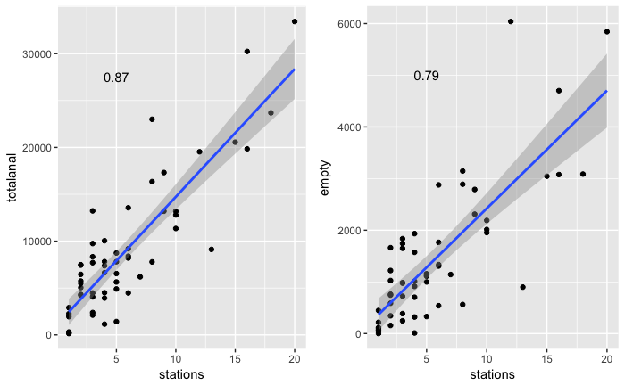

[figure not shown]

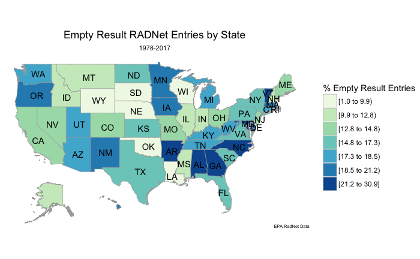

##### Hawaiian Subset

A subset of the data was used to limit initial data analysis manipulations and focus on a specific geographic area. Data from Hawaii was filtered and a simple state map showed that a majority of samples in Hawaii were from Honolulu. With a minor refinement, Honolulu was revealed to have the most varied of sample types with air-Filters being the most common type of sample.

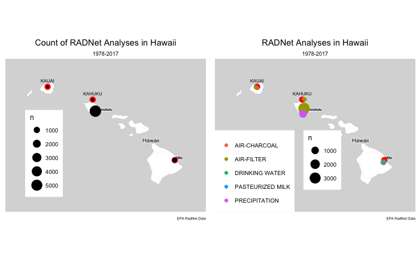

Further examination of the Hawaiian air samples confirms that around April 2011 378 air analyses were entered with one-half as air-charcoal (190) and the other half as air-filter analyses 188. Additionally these samples are predominantly from the same monitoring stations and less than half of the entries have unique sample IDs. However, upon a closer look, the duplication of sample IDs is due to multiple analyte tests and were not duplicated between air-filter and air-charcoal sample types. Perhaps more telling is that the air-filter sample spike is actualy earlier than the air-charcoal spike. So while this spike is an interesting detail, more information would be needed to establish a relationship between the empty air-charcoal and air-filter samples.

##### Empty Entries and Completed Samples Everywhere

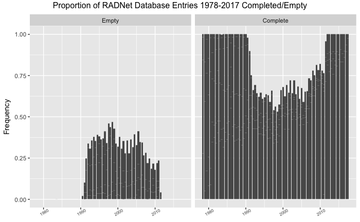

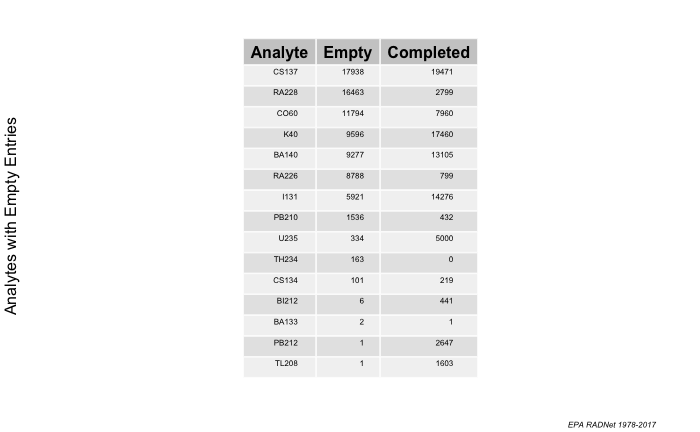

As a result of the incomplete observations and duplicate Sample IDs, it was considered that sample entry itself may have been duplicated. Grouping by sample ID yields 272,004 entries. Unique sample IDs account for 54% of the database. If the entries are grouped by both result date and sample ID there are 26,572 more samples, indicating that some results are entered on different dates. If the date ranges are increased (6 mos, 1 yrs, 2 yrs) the number of entries decreases giving some indication that the ID are not simply being re-issued. As date ranges are set as periods from the first date it is possible that any inconsistency between the non-grouped and date-range grouped data is an artefact of the arbitrary break, i.e., result entries may fall on both sides of any break and not actually be more than the interval apart. If data is grouped by location, the number of samples does not change, thus sample IDs are not be used across multiple locations.

```
[1] "Distinct Sample IDs:  " "272004"
[1] "Distinct Sample IDs by location:  " "272004"
[1] "Distinct Sample IDs by result date:  " "298576"
[1] "Distinct Sample IDs by Date and Location:  " "298576"
[1] "Distinct Sample IDs by Date Range (6 mos) and Location:  " "279265"
[1] "Distinct Sample IDs by Date Range (1 year) and Location:  " "277163"
[1] "Distinct Sample IDs by Date Range (2 years) and Location:  " "274677"
```